# Risk Factor Analysis

## Outcome Variable

**Outcome Variable:** ever_wasted

## Predictor Variables

**Intervention Variable:** feducyrs

**Adjustment Set:**

- arm
- W_mage
- meducyrs
- hhwealth_quart
- W_mhtcm
- W_mwtkg
- W_mbmi
- W_gagebrth
- W_birthwt
- W_birthlen
- single
- delta_W_mage
- delta_meducyrs
- delta_hhwealth_quart
- delta_W_mhtcm
- delta_W_mwtkg
- delta_W_mbmi
- delta_W_gagebrth
- delta_W_birthwt
- delta_W_birthlen
- delta_single

## Stratifying Variables

The analysis was stratified on these variable(s):

- agecat
- studyid
- country

## Data Summary

| agecat | studyid | country | feducyrs | ever_wasted | n_cell | n |
| --- | --- | --- | --- | --- | --- | --- |
| 0-24 months | ki0047075b-MAL-ED | BANGLADESH | High | 0 | 41 | 147 |
| 0-24 months | ki0047075b-MAL-ED | BANGLADESH | High | 1 | 13 | 147 |
| 0-24 months | ki0047075b-MAL-ED | BANGLADESH | Low | 0 | 23 | 147 |
| 0-24 months | ki0047075b-MAL-ED | BANGLADESH | Low | 1 | 16 | 147 |
| 0-24 months | ki0047075b-MAL-ED | BANGLADESH | Medium | 0 | 36 | 147 |
| 0-24 months | ki0047075b-MAL-ED | BANGLADESH | Medium | 1 | 18 | 147 |
| 0-24 months | ki0047075b-MAL-ED | INDIA | High | 0 | 22 | 147 |
| 0-24 months | ki0047075b-MAL-ED | INDIA | High | 1 | 22 | 147 |
| 0-24 months | ki0047075b-MAL-ED | INDIA | Low | 0 | 29 | 147 |
| 0-24 months | ki0047075b-MAL-ED | INDIA | Low | 1 | 30 | 147 |
| 0-24 months | ki0047075b-MAL-ED | INDIA | Medium | 0 | 27 | 147 |
| 0-24 months | ki0047075b-MAL-ED | INDIA | Medium | 1 | 17 | 147 |
| 0-24 months | ki0047075b-MAL-ED | NEPAL | High | 0 | 31 | 98 |
| 0-24 months | ki0047075b-MAL-ED | NEPAL | High | 1 | 11 | 98 |
| 0-24 months | ki0047075b-MAL-ED | NEPAL | Low | 0 | 17 | 98 |
| 0-24 months | ki0047075b-MAL-ED | NEPAL | Low | 1 | 11 | 98 |
| 0-24 months | ki0047075b-MAL-ED | NEPAL | Medium | 0 | 18 | 98 |
| 0-24 months | ki0047075b-MAL-ED | NEPAL | Medium | 1 | 10 | 98 |
| 0-24 months | ki0047075b-MAL-ED | PERU | High | 0 | 111 | 250 |
| 0-24 months | ki0047075b-MAL-ED | PERU | High | 1 | 9 | 250 |
| 0-24 months | ki0047075b-MAL-ED | PERU | Low | 0 | 65 | 250 |
| 0-24 months | ki0047075b-MAL-ED | PERU | Low | 1 | 4 | 250 |
| 0-24 months | ki0047075b-MAL-ED | PERU | Medium | 0 | 54 | 250 |
| 0-24 months | ki0047075b-MAL-ED | PERU | Medium | 1 | 7 | 250 |
| 0-24 months | ki0047075b-MAL-ED | SOUTH AFRICA | High | 0 | 36 | 110 |
| 0-24 months | ki0047075b-MAL-ED | SOUTH AFRICA | High | 1 | 7 | 110 |
| 0-24 months | ki0047075b-MAL-ED | SOUTH AFRICA | Low | 0 | 29 | 110 |
| 0-24 months | ki0047075b-MAL-ED | SOUTH AFRICA | Low | 1 | 8 | 110 |
| 0-24 months | ki0047075b-MAL-ED | SOUTH AFRICA | Medium | 0 | 23 | 110 |
| 0-24 months | ki0047075b-MAL-ED | SOUTH AFRICA | Medium | 1 | 7 | 110 |

[output cut: 330 more lines]

The following strata were considered:

- agecat: 0-24 months, studyid: ki0047075b-MAL-ED, country: BANGLADESH
- agecat: 0-24 months, studyid: ki0047075b-MAL-ED, country: INDIA
- agecat: 0-24 months, studyid: ki0047075b-MAL-ED, country: NEPAL
- agecat: 0-24 months, studyid: ki0047075b-MAL-ED, country: PERU
- agecat: 0-24 months, studyid: ki0047075b-MAL-ED, country: SOUTH AFRICA
- agecat: 0-24 months, studyid: ki0047075b-MAL-ED, country: TANZANIA, UNITED REPUBLIC OF
- agecat: 0-24 months, studyid: ki1000304b-SAS-CompFeed, country: INDIA
- agecat: 0-24 months, studyid: ki1000304b-SAS-FoodSuppl, country: INDIA
- agecat: 0-24 months, studyid: ki1017093b-PROVIDE, country: BANGLADESH
- agecat: 0-24 months, studyid: ki1017093c-NIH-Crypto, country: BANGLADESH
- agecat: 0-24 months, studyid: ki1066203-TanzaniaChild2, country: TANZANIA, UNITED REPUBLIC OF
- agecat: 0-24 months, studyid: ki1113344-GMS-Nepal, country: NEPAL
- agecat: 0-24 months, studyid: ki1119695-PROBIT, country: BELARUS
- agecat: 0-24 months, studyid: ki1126311-ZVITAMBO, country: ZIMBABWE
- agecat: 0-24 months, studyid: ki1135781-COHORTS, country: GUATEMALA
- agecat: 0-24 months, studyid: ki1135781-COHORTS, country: INDIA
- agecat: 0-24 months, studyid: ki1135781-COHORTS, country: PHILIPPINES
- agecat: 0-24 months, studyid: ki1148112-LCNI-5, country: MALAWI
- agecat: 0-24 months, studyid: kiGH5241-JiVitA-3, country: BANGLADESH
- agecat: 0-24 months, studyid: kiGH5241-JiVitA-4, country: BANGLADESH
- agecat: 0-6 months, studyid: ki0047075b-MAL-ED, country: BANGLADESH
- agecat: 0-6 months, studyid: ki0047075b-MAL-ED, country: INDIA
- agecat: 0-6 months, studyid: ki0047075b-MAL-ED, country: NEPAL
- agecat: 0-6 months, studyid: ki0047075b-MAL-ED, country: PERU
- agecat: 0-6 months, studyid: ki0047075b-MAL-ED, country: SOUTH AFRICA
- agecat: 0-6 months, studyid: ki0047075b-MAL-ED, country: TANZANIA, UNITED REPUBLIC OF
- agecat: 0-6 months, studyid: ki1000304b-SAS-CompFeed, country: INDIA
- agecat: 0-6 months, studyid: ki1000304b-SAS-FoodSuppl, country: INDIA
- agecat: 0-6 months, studyid: ki1017093b-PROVIDE, country: BANGLADESH
- agecat: 0-6 months, studyid: ki1017093c-NIH-Crypto, country: BANGLADESH
- agecat: 0-6 months, studyid: ki1066203-TanzaniaChild2, country: TANZANIA, UNITED REPUBLIC OF
- agecat: 0-6 months, studyid: ki1113344-GMS-Nepal, country: NEPAL
- agecat: 0-6 months, studyid: ki1119695-PROBIT, country: BELARUS
- agecat: 0-6 months, studyid: ki1126311-ZVITAMBO, country: ZIMBABWE
- agecat: 0-6 months, studyid: ki1135781-COHORTS, country: GUATEMALA
- agecat: 0-6 months, studyid: ki1135781-COHORTS, country: INDIA
- agecat: 0-6 months, studyid: ki1135781-COHORTS, country: PHILIPPINES
- agecat: 0-6 months, studyid: ki1148112-LCNI-5, country: MALAWI
- agecat: 0-6 months, studyid: kiGH5241-JiVitA-3, country: BANGLADESH
- agecat: 0-6 months, studyid: kiGH5241-JiVitA-4, country: BANGLADESH
- agecat: 6-24 months, studyid: ki0047075b-MAL-ED, country: BANGLADESH
- agecat: 6-24 months, studyid: ki0047075b-MAL-ED, country: INDIA
- agecat: 6-24 months, studyid: ki0047075b-MAL-ED, country: NEPAL
- agecat: 6-24 months, studyid: ki0047075b-MAL-ED, country: PERU
- agecat: 6-24 months, studyid: ki0047075b-MAL-ED, country: SOUTH AFRICA
- agecat: 6-24 months, studyid: ki0047075b-MAL-ED, country: TANZANIA, UNITED REPUBLIC OF
- agecat: 6-24 months, studyid: ki1000304b-SAS-CompFeed, country: INDIA
- agecat: 6-24 months, studyid: ki1000304b-SAS-FoodSuppl, country: INDIA
- agecat: 6-24 months, studyid: ki1017093b-PROVIDE, country: BANGLADESH
- agecat: 6-24 months, studyid: ki1017093c-NIH-Crypto, country: BANGLADESH
- agecat: 6-24 months, studyid: ki1066203-TanzaniaChild2, country: TANZANIA, UNITED REPUBLIC OF
- agecat: 6-24 months, studyid: ki1113344-GMS-Nepal, country: NEPAL
- agecat: 6-24 months, studyid: ki1119695-PROBIT, country: BELARUS
- agecat: 6-24 months, studyid: ki1126311-ZVITAMBO, country: ZIMBABWE
- agecat: 6-24 months, studyid: ki1135781-COHORTS, country: GUATEMALA
- agecat: 6-24 months, studyid: ki1135781-COHORTS, country: INDIA
- agecat: 6-24 months, studyid: ki1135781-COHORTS, country: PHILIPPINES
- agecat: 6-24 months, studyid: ki1148112-LCNI-5, country: MALAWI
- agecat: 6-24 months, studyid: kiGH5241-JiVitA-3, country: BANGLADESH
- agecat: 6-24 months, studyid: kiGH5241-JiVitA-4, country: BANGLADESH

### Dropped Strata

Some strata were dropped due to rare outcomes:

- agecat: 0-24 months, studyid: ki0047075b-MAL-ED, country: PERU
- agecat: 0-24 months, studyid: ki0047075b-MAL-ED, country: TANZANIA, UNITED REPUBLIC OF
- agecat: 0-6 months, studyid: ki0047075b-MAL-ED, country: NEPAL
- agecat: 0-6 months, studyid: ki0047075b-MAL-ED, country: PERU
- agecat: 0-6 months, studyid: ki0047075b-MAL-ED, country: SOUTH AFRICA
- agecat: 0-6 months, studyid: ki0047075b-MAL-ED, country: TANZANIA, UNITED REPUBLIC OF
- agecat: 0-6 months, studyid: ki1148112-LCNI-5, country: MALAWI
- agecat: 6-24 months, studyid: ki0047075b-MAL-ED, country: NEPAL
- agecat: 6-24 months, studyid: ki0047075b-MAL-ED, country: PERU
- agecat: 6-24 months, studyid: ki0047075b-MAL-ED, country: SOUTH AFRICA
- agecat: 6-24 months, studyid: ki0047075b-MAL-ED, country: TANZANIA, UNITED REPUBLIC OF

## Methods Detail

We’re interested in the causal parameters $E[Y_a]$ for all values of $a \in \mathcal{A}$. These parameters represent the mean outcome if, possibly contrary to fact, we intervened to set all units to have $A=a$. Under the randomization and positivity assumptions, these are identified by the statistical parameters $\psi_a=E_W[E_{Y|A,W}(Y|A=a,W)]$. In addition, we’re interested in the mean of $Y$, $E[Y]$ under no intervention (the observed mean). We will estimate these parameters by using SuperLearner to fit the relevant likelihood factors – $E_{Y|A,W}(Y|A=a,W)$ and $p(A=a|W)$, and then updating our likelihood fit using a joint TMLE.

For unadjusted analyses ($W=\{\}$), initial likelihoods were estimated using Lrnr_glm to estimate the simple $E(Y|A)$ and Lrnr_mean to estimate $p(A)$. For adjusted analyses, a small library containing Lrnr_glmnet, Lrnr_xgboost, and Lrnr_mean was used.

Having estimated these parameters, we will then use the delta method to estimate relative risks and attributable risks relative to a prespecified baseline level of $A$.

# Results Detail

## Results Plots

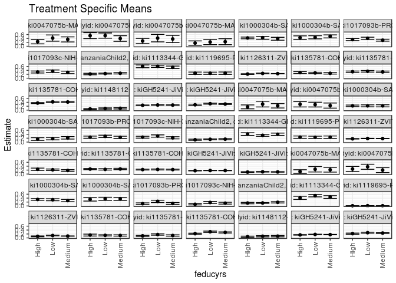

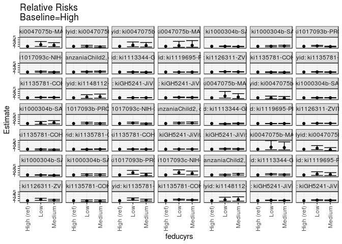

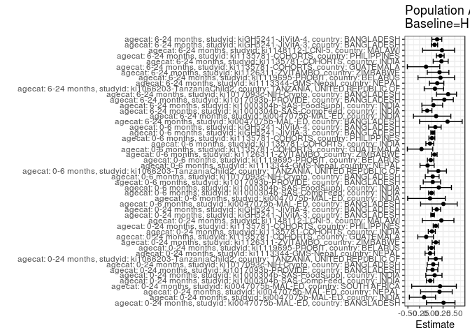

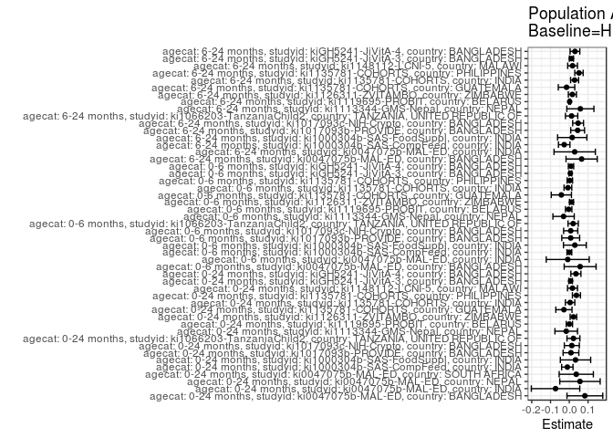

## Results Table

### Parameter: TSM

| agecat | studyid | country | intervention_level | baseline_level | estimate | ci_lower | ci_upper |
| --- | --- | --- | --- | --- | --- | --- | --- |
| 0-24 months | ki0047075b-MAL-ED | BANGLADESH | High | NA | 0.2366255 | 0.1232566 | 0.3499943 |
| 0-24 months | ki0047075b-MAL-ED | BANGLADESH | Low | NA | 0.4184472 | 0.2592287 | 0.5776658 |
| 0-24 months | ki0047075b-MAL-ED | BANGLADESH | Medium | NA | 0.3507553 | 0.2214879 | 0.4800228 |
| 0-24 months | ki0047075b-MAL-ED | INDIA | High | NA | 0.5425884 | 0.3908532 | 0.6943237 |
| 0-24 months | ki0047075b-MAL-ED | INDIA | Low | NA | 0.5459606 | 0.4142455 | 0.6776758 |
| 0-24 months | ki0047075b-MAL-ED | INDIA | Medium | NA | 0.3969231 | 0.2529584 | 0.5408878 |
| 0-24 months | ki0047075b-MAL-ED | NEPAL | High | NA | 0.2695875 | 0.1350325 | 0.4041424 |
| 0-24 months | ki0047075b-MAL-ED | NEPAL | Low | NA | 0.4154756 | 0.2256311 | 0.6053201 |
| 0-24 months | ki0047075b-MAL-ED | NEPAL | Medium | NA | 0.3725789 | 0.1879442 | 0.5572136 |
| 0-24 months | ki0047075b-MAL-ED | SOUTH AFRICA | High | NA | 0.1627907 | 0.0519425 | 0.2736389 |
| 0-24 months | ki0047075b-MAL-ED | SOUTH AFRICA | Low | NA | 0.2162162 | 0.0829646 | 0.3494679 |
| 0-24 months | ki0047075b-MAL-ED | SOUTH AFRICA | Medium | NA | 0.2333333 | 0.0812918 | 0.3853749 |
| 0-24 months | ki1000304b-SAS-CompFeed | INDIA | High | NA | 0.4249498 | 0.3808825 | 0.4690171 |
| 0-24 months | ki1000304b-SAS-CompFeed | INDIA | Low | NA | 0.4311067 | 0.3585021 | 0.5037113 |
| 0-24 months | ki1000304b-SAS-CompFeed | INDIA | Medium | NA | 0.3848064 | 0.3111227 | 0.4584900 |
| 0-24 months | ki1000304b-SAS-FoodSuppl | INDIA | High | NA | 0.4380236 | 0.3441376 | 0.5319095 |
| 0-24 months | ki1000304b-SAS-FoodSuppl | INDIA | Low | NA | 0.4592010 | 0.3782601 | 0.5401419 |
| 0-24 months | ki1000304b-SAS-FoodSuppl | INDIA | Medium | NA | 0.5046614 | 0.4269216 | 0.5824012 |
| 0-24 months | ki1017093b-PROVIDE | BANGLADESH | High | NA | 0.3423850 | 0.2877048 | 0.3970652 |
| 0-24 months | ki1017093b-PROVIDE | BANGLADESH | Low | NA | 0.4067123 | 0.3493844 | 0.4640402 |
| 0-24 months | ki1017093b-PROVIDE | BANGLADESH | Medium | NA | 0.3100808 | 0.2610722 | 0.3590894 |
| 0-24 months | ki1017093c-NIH-Crypto | BANGLADESH | High | NA | 0.3162400 | 0.2652211 | 0.3672588 |
| 0-24 months | ki1017093c-NIH-Crypto | BANGLADESH | Low | NA | 0.3599108 | 0.2986073 | 0.4212143 |
| 0-24 months | ki1017093c-NIH-Crypto | BANGLADESH | Medium | NA | 0.2975613 | 0.2343829 | 0.3607396 |
| 0-24 months | ki1066203-TanzaniaChild2 | TANZANIA, UNITED REPUBLIC OF | High | NA | 0.2144689 | 0.1766577 | 0.2522802 |
| 0-24 months | ki1066203-TanzaniaChild2 | TANZANIA, UNITED REPUBLIC OF | Low | NA | 0.2363343 | 0.2130310 | 0.2596377 |
| 0-24 months | ki1066203-TanzaniaChild2 | TANZANIA, UNITED REPUBLIC OF | Medium | NA | 0.2522770 | 0.2188897 | 0.2856643 |
| 0-24 months | ki1113344-GMS-Nepal | NEPAL | High | NA | 0.6069860 | 0.5368726 | 0.6770995 |
| 0-24 months | ki1113344-GMS-Nepal | NEPAL | Low | NA | 0.6065107 | 0.5518505 | 0.6611709 |
| 0-24 months | ki1113344-GMS-Nepal | NEPAL | Medium | NA | 0.5590377 | 0.4960604 | 0.6220151 |

[output cut: 117 more lines]

### Parameter: E(Y)

| agecat | studyid | country | intervention_level | baseline_level | estimate | ci_lower | ci_upper |
| --- | --- | --- | --- | --- | --- | --- | --- |
| 0-24 months | ki0047075b-MAL-ED | BANGLADESH | NA | NA | 0.3197279 | 0.2440789 | 0.3953769 |
| 0-24 months | ki0047075b-MAL-ED | INDIA | NA | NA | 0.4693878 | 0.3884360 | 0.5503395 |
| 0-24 months | ki0047075b-MAL-ED | NEPAL | NA | NA | 0.3265306 | 0.2332088 | 0.4198524 |
| 0-24 months | ki0047075b-MAL-ED | SOUTH AFRICA | NA | NA | 0.2000000 | 0.1249078 | 0.2750922 |
| 0-24 months | ki1000304b-SAS-CompFeed | INDIA | NA | NA | 0.4145695 | 0.3576236 | 0.4715155 |
| 0-24 months | ki1000304b-SAS-FoodSuppl | INDIA | NA | NA | 0.4712919 | 0.4233811 | 0.5192026 |
| 0-24 months | ki1017093b-PROVIDE | BANGLADESH | NA | NA | 0.3514286 | 0.3160364 | 0.3868207 |
| 0-24 months | ki1017093c-NIH-Crypto | BANGLADESH | NA | NA | 0.3298153 | 0.2963239 | 0.3633067 |
| 0-24 months | ki1066203-TanzaniaChild2 | TANZANIA, UNITED REPUBLIC OF | NA | NA | 0.2366765 | 0.2196074 | 0.2537455 |
| 0-24 months | ki1113344-GMS-Nepal | NEPAL | NA | NA | 0.5906433 | 0.5537666 | 0.6275199 |
| 0-24 months | ki1119695-PROBIT | BELARUS | NA | NA | 0.2556543 | 0.1980936 | 0.3132150 |
| 0-24 months | ki1126311-ZVITAMBO | ZIMBABWE | NA | NA | 0.2337854 | 0.2266636 | 0.2409072 |
| 0-24 months | ki1135781-COHORTS | GUATEMALA | NA | NA | 0.2601297 | 0.2356425 | 0.2846169 |
| 0-24 months | ki1135781-COHORTS | INDIA | NA | NA | 0.3365584 | 0.3122030 | 0.3609138 |
| 0-24 months | ki1135781-COHORTS | PHILIPPINES | NA | NA | 0.4013250 | 0.3833827 | 0.4192673 |
| 0-24 months | ki1148112-LCNI-5 | MALAWI | NA | NA | 0.0799508 | 0.0612962 | 0.0986054 |
| 0-24 months | kiGH5241-JiVitA-3 | BANGLADESH | NA | NA | 0.2573354 | 0.2507501 | 0.2639207 |
| 0-24 months | kiGH5241-JiVitA-4 | BANGLADESH | NA | NA | 0.3100246 | 0.2953385 | 0.3247108 |
| 0-6 months | ki0047075b-MAL-ED | BANGLADESH | NA | NA | 0.2244898 | 0.1568093 | 0.2921703 |
| 0-6 months | ki0047075b-MAL-ED | INDIA | NA | NA | 0.2925170 | 0.2187257 | 0.3663083 |
| 0-6 months | ki1000304b-SAS-CompFeed | INDIA | NA | NA | 0.2197071 | 0.1750081 | 0.2644060 |
| 0-6 months | ki1000304b-SAS-FoodSuppl | INDIA | NA | NA | 0.1866029 | 0.1492099 | 0.2239959 |
| 0-6 months | ki1017093b-PROVIDE | BANGLADESH | NA | NA | 0.2585714 | 0.2261125 | 0.2910304 |
| 0-6 months | ki1017093c-NIH-Crypto | BANGLADESH | NA | NA | 0.2572559 | 0.2261171 | 0.2883948 |
| 0-6 months | ki1066203-TanzaniaChild2 | TANZANIA, UNITED REPUBLIC OF | NA | NA | 0.1397398 | 0.1258162 | 0.1536634 |
| 0-6 months | ki1113344-GMS-Nepal | NEPAL | NA | NA | 0.3771930 | 0.3408437 | 0.4135423 |
| 0-6 months | ki1119695-PROBIT | BELARUS | NA | NA | 0.2487739 | 0.1904535 | 0.3070943 |
| 0-6 months | ki1126311-ZVITAMBO | ZIMBABWE | NA | NA | 0.1794777 | 0.1729988 | 0.1859566 |
| 0-6 months | ki1135781-COHORTS | GUATEMALA | NA | NA | 0.2006018 | 0.1757323 | 0.2254713 |
| 0-6 months | ki1135781-COHORTS | INDIA | NA | NA | 0.2462950 | 0.2238538 | 0.2687361 |
| 0-6 months | ki1135781-COHORTS | PHILIPPINES | NA | NA | 0.2291594 | 0.2137721 | 0.2445467 |
| 0-6 months | kiGH5241-JiVitA-3 | BANGLADESH | NA | NA | 0.1757592 | 0.1700164 | 0.1815020 |
| 0-6 months | kiGH5241-JiVitA-4 | BANGLADESH | NA | NA | 0.1079224 | 0.0978937 | 0.1179511 |
| 6-24 months | ki0047075b-MAL-ED | BANGLADESH | NA | NA | 0.1908397 | 0.1232893 | 0.2583901 |
| 6-24 months | ki0047075b-MAL-ED | INDIA | NA | NA | 0.2846715 | 0.2088306 | 0.3605124 |
| 6-24 months | ki1000304b-SAS-CompFeed | INDIA | NA | NA | 0.3051948 | 0.2633957 | 0.3469939 |
| 6-24 months | ki1000304b-SAS-FoodSuppl | INDIA | NA | NA | 0.3557214 | 0.3088651 | 0.4025777 |
| 6-24 months | ki1017093b-PROVIDE | BANGLADESH | NA | NA | 0.1609756 | 0.1319065 | 0.1900447 |
| 6-24 months | ki1017093c-NIH-Crypto | BANGLADESH | NA | NA | 0.1315068 | 0.1069744 | 0.1560393 |
| 6-24 months | ki1066203-TanzaniaChild2 | TANZANIA, UNITED REPUBLIC OF | NA | NA | 0.1602787 | 0.1442326 | 0.1763249 |
| 6-24 months | ki1113344-GMS-Nepal | NEPAL | NA | NA | 0.4719864 | 0.4316361 | 0.5123367 |
| 6-24 months | ki1119695-PROBIT | BELARUS | NA | NA | 0.0102327 | 0.0075781 | 0.0128874 |
| 6-24 months | ki1126311-ZVITAMBO | ZIMBABWE | NA | NA | 0.0946306 | 0.0890328 | 0.1002285 |
| 6-24 months | ki1135781-COHORTS | GUATEMALA | NA | NA | 0.1288889 | 0.1093000 | 0.1484778 |
| 6-24 months | ki1135781-COHORTS | INDIA | NA | NA | 0.1323843 | 0.1146569 | 0.1501118 |
| 6-24 months | ki1135781-COHORTS | PHILIPPINES | NA | NA | 0.2666667 | 0.2498425 | 0.2834908 |
| 6-24 months | ki1148112-LCNI-5 | MALAWI | NA | NA | 0.0773067 | 0.0588111 | 0.0958024 |
| 6-24 months | kiGH5241-JiVitA-3 | BANGLADESH | NA | NA | 0.1643382 | 0.1581062 | 0.1705701 |
| 6-24 months | kiGH5241-JiVitA-4 | BANGLADESH | NA | NA | 0.2467286 | 0.2329282 | 0.2605290 |

### Parameter: RR

| agecat | studyid | country | intervention_level | baseline_level | estimate | ci_lower | ci_upper |
| --- | --- | --- | --- | --- | --- | --- | --- |
| 0-24 months | ki0047075b-MAL-ED | BANGLADESH | High | High | 1.0000000 | 1.0000000 | 1.000000 |
| 0-24 months | ki0047075b-MAL-ED | BANGLADESH | Low | High | 1.7683948 | 0.9595894 | 3.258915 |
| 0-24 months | ki0047075b-MAL-ED | BANGLADESH | Medium | High | 1.4823229 | 0.8080275 | 2.719315 |
| 0-24 months | ki0047075b-MAL-ED | INDIA | High | High | 1.0000000 | 1.0000000 | 1.000000 |
| 0-24 months | ki0047075b-MAL-ED | INDIA | Low | High | 1.0062150 | 0.6920090 | 1.463086 |
| 0-24 months | ki0047075b-MAL-ED | INDIA | Medium | High | 0.7315363 | 0.4622653 | 1.157658 |
| 0-24 months | ki0047075b-MAL-ED | NEPAL | High | High | 1.0000000 | 1.0000000 | 1.000000 |
| 0-24 months | ki0047075b-MAL-ED | NEPAL | Low | High | 1.5411532 | 0.7791658 | 3.048328 |
| 0-24 months | ki0047075b-MAL-ED | NEPAL | Medium | High | 1.3820334 | 0.6840951 | 2.792033 |
| 0-24 months | ki0047075b-MAL-ED | SOUTH AFRICA | High | High | 1.0000000 | 1.0000000 | 1.000000 |
| 0-24 months | ki0047075b-MAL-ED | SOUTH AFRICA | Low | High | 1.3281853 | 0.5301512 | 3.327496 |
| 0-24 months | ki0047075b-MAL-ED | SOUTH AFRICA | Medium | High | 1.4333333 | 0.5585186 | 3.678381 |
| 0-24 months | ki1000304b-SAS-CompFeed | INDIA | High | High | 1.0000000 | 1.0000000 | 1.000000 |
| 0-24 months | ki1000304b-SAS-CompFeed | INDIA | Low | High | 1.0144887 | 0.8940072 | 1.151207 |
| 0-24 months | ki1000304b-SAS-CompFeed | INDIA | Medium | High | 0.9055337 | 0.7988990 | 1.026402 |
| 0-24 months | ki1000304b-SAS-FoodSuppl | INDIA | High | High | 1.0000000 | 1.0000000 | 1.000000 |
| 0-24 months | ki1000304b-SAS-FoodSuppl | INDIA | Low | High | 1.0483478 | 0.7940415 | 1.384100 |
| 0-24 months | ki1000304b-SAS-FoodSuppl | INDIA | Medium | High | 1.1521330 | 0.8843534 | 1.500995 |
| 0-24 months | ki1017093b-PROVIDE | BANGLADESH | High | High | 1.0000000 | 1.0000000 | 1.000000 |
| 0-24 months | ki1017093b-PROVIDE | BANGLADESH | Low | High | 1.1878801 | 0.9760515 | 1.445681 |
| 0-24 months | ki1017093b-PROVIDE | BANGLADESH | Medium | High | 0.9056495 | 0.7402551 | 1.107998 |
| 0-24 months | ki1017093c-NIH-Crypto | BANGLADESH | High | High | 1.0000000 | 1.0000000 | 1.000000 |
| 0-24 months | ki1017093c-NIH-Crypto | BANGLADESH | Low | High | 1.1380939 | 0.9026997 | 1.434871 |
| 0-24 months | ki1017093c-NIH-Crypto | BANGLADESH | Medium | High | 0.9409351 | 0.7231795 | 1.224259 |
| 0-24 months | ki1066203-TanzaniaChild2 | TANZANIA, UNITED REPUBLIC OF | High | High | 1.0000000 | 1.0000000 | 1.000000 |
| 0-24 months | ki1066203-TanzaniaChild2 | TANZANIA, UNITED REPUBLIC OF | Low | High | 1.1019514 | 0.9010115 | 1.347704 |
| 0-24 months | ki1066203-TanzaniaChild2 | TANZANIA, UNITED REPUBLIC OF | Medium | High | 1.1762871 | 0.9440245 | 1.465694 |
| 0-24 months | ki1113344-GMS-Nepal | NEPAL | High | High | 1.0000000 | 1.0000000 | 1.000000 |
| 0-24 months | ki1113344-GMS-Nepal | NEPAL | Low | High | 0.9992169 | 0.8657857 | 1.153212 |
| 0-24 months | ki1113344-GMS-Nepal | NEPAL | Medium | High | 0.9210059 | 0.7868225 | 1.078073 |

[output cut: 117 more lines]

### Parameter: PAR

| agecat | studyid | country | intervention_level | baseline_level | estimate | ci_lower | ci_upper |
| --- | --- | --- | --- | --- | --- | --- | --- |
| 0-24 months | ki0047075b-MAL-ED | BANGLADESH | High | NA | 0.0831024 | -0.0122868 | 0.1784916 |
| 0-24 months | ki0047075b-MAL-ED | INDIA | High | NA | -0.0732007 | -0.2023763 | 0.0559749 |
| 0-24 months | ki0047075b-MAL-ED | NEPAL | High | NA | 0.0569432 | -0.0507096 | 0.1645960 |
| 0-24 months | ki0047075b-MAL-ED | SOUTH AFRICA | High | NA | 0.0372093 | -0.0540031 | 0.1284218 |
| 0-24 months | ki1000304b-SAS-CompFeed | INDIA | High | NA | -0.0103802 | -0.0406670 | 0.0199065 |
| 0-24 months | ki1000304b-SAS-FoodSuppl | INDIA | High | NA | 0.0332683 | -0.0475397 | 0.1140763 |
| 0-24 months | ki1017093b-PROVIDE | BANGLADESH | High | NA | 0.0090436 | -0.0328546 | 0.0509418 |
| 0-24 months | ki1017093c-NIH-Crypto | BANGLADESH | High | NA | 0.0135753 | -0.0264496 | 0.0536003 |
| 0-24 months | ki1066203-TanzaniaChild2 | TANZANIA, UNITED REPUBLIC OF | High | NA | 0.0222075 | -0.0122052 | 0.0566203 |
| 0-24 months | ki1113344-GMS-Nepal | NEPAL | High | NA | -0.0163428 | -0.0764698 | 0.0437843 |
| 0-24 months | ki1119695-PROBIT | BELARUS | High | NA | 0.0006130 | -0.0162061 | 0.0174320 |
| 0-24 months | ki1126311-ZVITAMBO | ZIMBABWE | High | NA | 0.0221529 | 0.0046830 | 0.0396228 |
| 0-24 months | ki1135781-COHORTS | GUATEMALA | High | NA | -0.0286210 | -0.0717738 | 0.0145318 |
| 0-24 months | ki1135781-COHORTS | INDIA | High | NA | 0.0043221 | -0.0208168 | 0.0294610 |
| 0-24 months | ki1135781-COHORTS | PHILIPPINES | High | NA | 0.0381352 | 0.0166674 | 0.0596030 |
| 0-24 months | ki1148112-LCNI-5 | MALAWI | High | NA | 0.0170459 | -0.0094458 | 0.0435377 |
| 0-24 months | kiGH5241-JiVitA-3 | BANGLADESH | High | NA | 0.0070459 | -0.0026390 | 0.0167309 |
| 0-24 months | kiGH5241-JiVitA-4 | BANGLADESH | High | NA | 0.0352977 | 0.0084661 | 0.0621293 |
| 0-6 months | ki0047075b-MAL-ED | BANGLADESH | High | NA | 0.0578231 | -0.0271469 | 0.1427932 |
| 0-6 months | ki0047075b-MAL-ED | INDIA | High | NA | -0.0082565 | -0.1228481 | 0.1063350 |
| 0-6 months | ki1000304b-SAS-CompFeed | INDIA | High | NA | 0.0003606 | -0.0124231 | 0.0131443 |
| 0-6 months | ki1000304b-SAS-FoodSuppl | INDIA | High | NA | 0.0297182 | -0.0310498 | 0.0904862 |
| 0-6 months | ki1017093b-PROVIDE | BANGLADESH | High | NA | 0.0076710 | -0.0399430 | 0.0552849 |
| 0-6 months | ki1017093c-NIH-Crypto | BANGLADESH | High | NA | 0.0075085 | -0.0301403 | 0.0451574 |
| 0-6 months | ki1066203-TanzaniaChild2 | TANZANIA, UNITED REPUBLIC OF | High | NA | 0.0206283 | -0.0068353 | 0.0480919 |
| 0-6 months | ki1113344-GMS-Nepal | NEPAL | High | NA | -0.0304056 | -0.0871840 | 0.0263728 |
| 0-6 months | ki1119695-PROBIT | BELARUS | High | NA | -0.0032388 | -0.0203368 | 0.0138592 |
| 0-6 months | ki1126311-ZVITAMBO | ZIMBABWE | High | NA | 0.0117623 | 0.0011516 | 0.0223730 |
| 0-6 months | ki1135781-COHORTS | GUATEMALA | High | NA | -0.0422456 | -0.0960878 | 0.0115966 |
| 0-6 months | ki1135781-COHORTS | INDIA | High | NA | -0.0073010 | -0.0278726 | 0.0132706 |
| 0-6 months | ki1135781-COHORTS | PHILIPPINES | High | NA | 0.0029951 | -0.0114920 | 0.0174821 |
| 0-6 months | kiGH5241-JiVitA-3 | BANGLADESH | High | NA | 0.0057051 | -0.0018115 | 0.0132216 |
| 0-6 months | kiGH5241-JiVitA-4 | BANGLADESH | High | NA | 0.0092080 | -0.0049629 | 0.0233790 |
| 6-24 months | ki0047075b-MAL-ED | BANGLADESH | High | NA | 0.0658397 | -0.0173452 | 0.1490246 |
| 6-24 months | ki0047075b-MAL-ED | INDIA | High | NA | 0.0288576 | -0.0812767 | 0.1389918 |
| 6-24 months | ki1000304b-SAS-CompFeed | INDIA | High | NA | -0.0269816 | -0.0576691 | 0.0037058 |
| 6-24 months | ki1000304b-SAS-FoodSuppl | INDIA | High | NA | 0.0157584 | -0.0623716 | 0.0938883 |
| 6-24 months | ki1017093b-PROVIDE | BANGLADESH | High | NA | 0.0446157 | 0.0078287 | 0.0814028 |
| 6-24 months | ki1017093c-NIH-Crypto | BANGLADESH | High | NA | 0.0470535 | 0.0181511 | 0.0759560 |
| 6-24 months | ki1066203-TanzaniaChild2 | TANZANIA, UNITED REPUBLIC OF | High | NA | 0.0123827 | -0.0204297 | 0.0451952 |
| 6-24 months | ki1113344-GMS-Nepal | NEPAL | High | NA | 0.0591501 | -0.0130887 | 0.1313889 |
| 6-24 months | ki1119695-PROBIT | BELARUS | High | NA | 0.0019937 | -0.0021307 | 0.0061182 |
| 6-24 months | ki1126311-ZVITAMBO | ZIMBABWE | High | NA | 0.0165426 | -0.0050309 | 0.0381162 |
| 6-24 months | ki1135781-COHORTS | GUATEMALA | High | NA | -0.0146264 | -0.0585125 | 0.0292598 |
| 6-24 months | ki1135781-COHORTS | INDIA | High | NA | 0.0285044 | 0.0071926 | 0.0498161 |
| 6-24 months | ki1135781-COHORTS | PHILIPPINES | High | NA | 0.0516644 | 0.0293705 | 0.0739583 |
| 6-24 months | ki1148112-LCNI-5 | MALAWI | High | NA | 0.0174897 | -0.0084715 | 0.0434510 |
| 6-24 months | kiGH5241-JiVitA-3 | BANGLADESH | High | NA | 0.0114741 | 0.0004700 | 0.0224782 |
| 6-24 months | kiGH5241-JiVitA-4 | BANGLADESH | High | NA | 0.0303251 | 0.0044375 | 0.0562128 |

### Parameter: PAF

| agecat | studyid | country | intervention_level | baseline_level | estimate | ci_lower | ci_upper |
| --- | --- | --- | --- | --- | --- | --- | --- |
| 0-24 months | ki0047075b-MAL-ED | BANGLADESH | High | NA | 0.2599161 | -0.1044494 | 0.5040749 |
| 0-24 months | ki0047075b-MAL-ED | INDIA | High | NA | -0.1559493 | -0.4686858 | 0.0901943 |
| 0-24 months | ki0047075b-MAL-ED | NEPAL | High | NA | 0.1743884 | -0.2283383 | 0.4450760 |
| 0-24 months | ki0047075b-MAL-ED | SOUTH AFRICA | High | NA | 0.1860465 | -0.4198366 | 0.5333827 |
| 0-24 months | ki1000304b-SAS-CompFeed | INDIA | High | NA | -0.0250386 | -0.1031881 | 0.0475748 |
| 0-24 months | ki1000304b-SAS-FoodSuppl | INDIA | High | NA | 0.0705896 | -0.1178745 | 0.2272803 |
| 0-24 months | ki1017093b-PROVIDE | BANGLADESH | High | NA | 0.0257338 | -0.1011043 | 0.1379612 |
| 0-24 months | ki1017093c-NIH-Crypto | BANGLADESH | High | NA | 0.0411604 | -0.0880775 | 0.1550479 |
| 0-24 months | ki1066203-TanzaniaChild2 | TANZANIA, UNITED REPUBLIC OF | High | NA | 0.0938308 | -0.0637586 | 0.2280743 |
| 0-24 months | ki1113344-GMS-Nepal | NEPAL | High | NA | -0.0276694 | -0.1347231 | 0.0692844 |
| 0-24 months | ki1119695-PROBIT | BELARUS | High | NA | 0.0023976 | -0.0655866 | 0.0660444 |
| 0-24 months | ki1126311-ZVITAMBO | ZIMBABWE | High | NA | 0.0947575 | 0.0169107 | 0.1664399 |
| 0-24 months | ki1135781-COHORTS | GUATEMALA | High | NA | -0.1100258 | -0.2893561 | 0.0443624 |
| 0-24 months | ki1135781-COHORTS | INDIA | High | NA | 0.0128420 | -0.0647120 | 0.0847470 |
| 0-24 months | ki1135781-COHORTS | PHILIPPINES | High | NA | 0.0950232 | 0.0399359 | 0.1469497 |
| 0-24 months | ki1148112-LCNI-5 | MALAWI | High | NA | 0.2132054 | -0.1942517 | 0.4816455 |
| 0-24 months | kiGH5241-JiVitA-3 | BANGLADESH | High | NA | 0.0273804 | -0.0109693 | 0.0642752 |
| 0-24 months | kiGH5241-JiVitA-4 | BANGLADESH | High | NA | 0.1138545 | 0.0220613 | 0.1970317 |
| 0-6 months | ki0047075b-MAL-ED | BANGLADESH | High | NA | 0.2575758 | -0.2285454 | 0.5513444 |
| 0-6 months | ki0047075b-MAL-ED | INDIA | High | NA | -0.0282259 | -0.5047777 | 0.2974056 |
| 0-6 months | ki1000304b-SAS-CompFeed | INDIA | High | NA | 0.0016414 | -0.0581359 | 0.0580418 |
| 0-6 months | ki1000304b-SAS-FoodSuppl | INDIA | High | NA | 0.1592591 | -0.2371087 | 0.4286312 |
| 0-6 months | ki1017093b-PROVIDE | BANGLADESH | High | NA | 0.0296667 | -0.1729462 | 0.1972805 |
| 0-6 months | ki1017093c-NIH-Crypto | BANGLADESH | High | NA | 0.0291870 | -0.1287737 | 0.1650427 |
| 0-6 months | ki1066203-TanzaniaChild2 | TANZANIA, UNITED REPUBLIC OF | High | NA | 0.1476194 | -0.0728327 | 0.3227717 |
| 0-6 months | ki1113344-GMS-Nepal | NEPAL | High | NA | -0.0806102 | -0.2419981 | 0.0598066 |
| 0-6 months | ki1119695-PROBIT | BELARUS | High | NA | -0.0130190 | -0.0842732 | 0.0535527 |
| 0-6 months | ki1126311-ZVITAMBO | ZIMBABWE | High | NA | 0.0655363 | 0.0045732 | 0.1227658 |
| 0-6 months | ki1135781-COHORTS | GUATEMALA | High | NA | -0.2105943 | -0.5112717 | 0.0302614 |
| 0-6 months | ki1135781-COHORTS | INDIA | High | NA | -0.0296434 | -0.1166973 | 0.0506241 |
| 0-6 months | ki1135781-COHORTS | PHILIPPINES | High | NA | 0.0130699 | -0.0522079 | 0.0742979 |
| 0-6 months | kiGH5241-JiVitA-3 | BANGLADESH | High | NA | 0.0324595 | -0.0113415 | 0.0743635 |
| 0-6 months | kiGH5241-JiVitA-4 | BANGLADESH | High | NA | 0.0853210 | -0.0571285 | 0.2085753 |
| 6-24 months | ki0047075b-MAL-ED | BANGLADESH | High | NA | 0.3450000 | -0.2511462 | 0.6570944 |
| 6-24 months | ki0047075b-MAL-ED | INDIA | High | NA | 0.1013715 | -0.3817356 | 0.4155660 |
| 6-24 months | ki1000304b-SAS-CompFeed | INDIA | High | NA | -0.0884080 | -0.1991589 | 0.0121143 |
| 6-24 months | ki1000304b-SAS-FoodSuppl | INDIA | High | NA | 0.0442998 | -0.2026407 | 0.2405355 |
| 6-24 months | ki1017093b-PROVIDE | BANGLADESH | High | NA | 0.2771584 | 0.0162856 | 0.4688499 |
| 6-24 months | ki1017093c-NIH-Crypto | BANGLADESH | High | NA | 0.3578030 | 0.1088466 | 0.5372099 |
| 6-24 months | ki1066203-TanzaniaChild2 | TANZANIA, UNITED REPUBLIC OF | High | NA | 0.0772575 | -0.1518342 | 0.2607846 |
| 6-24 months | ki1113344-GMS-Nepal | NEPAL | High | NA | 0.1253217 | -0.0424021 | 0.2660585 |
| 6-24 months | ki1119695-PROBIT | BELARUS | High | NA | 0.1948379 | -0.2849594 | 0.4954813 |
| 6-24 months | ki1126311-ZVITAMBO | ZIMBABWE | High | NA | 0.1748125 | -0.0875915 | 0.3739062 |
| 6-24 months | ki1135781-COHORTS | GUATEMALA | High | NA | -0.1134803 | -0.5116912 | 0.1798336 |
| 6-24 months | ki1135781-COHORTS | INDIA | High | NA | 0.2153153 | 0.0399000 | 0.3586812 |
| 6-24 months | ki1135781-COHORTS | PHILIPPINES | High | NA | 0.1937414 | 0.1062026 | 0.2727067 |
| 6-24 months | ki1148112-LCNI-5 | MALAWI | High | NA | 0.2262383 | -0.1883115 | 0.4961698 |
| 6-24 months | kiGH5241-JiVitA-3 | BANGLADESH | High | NA | 0.0698201 | 0.0006365 | 0.1342143 |
| 6-24 months | kiGH5241-JiVitA-4 | BANGLADESH | High | NA | 0.1229089 | 0.0104824 | 0.2225618 |